# MERA User Guide (v4.4)

Method Evaluation and Risk Assessment

T. Carruthers (UBC)

2019-07-31

[figure not shown]

# 1 Introduction

## 1.1 Overview

Fisheries managers are in need of tools to inform decision making often in the face of imperfect information and high uncertainty. By linking a simple questionnaire to an operating model and sophisticated simulation software, MERA provides managers with an accessible and powerful tool for identifying species at risk, selecting management procedures that can achieve their performance objectives, and calculating stock status.

MERA is intended to better account for uncertainty in the fishery system, prioritizing robust management options and identifying value in alternative data collection and research programs. By focusing on operational modelling, MERA can provide quantitative outputs that are central to fishery legal frameworks and eco-certification standards, for example probabilistic estimates of stock status relative to reference levels. MERA lessens the reliance on subjective, qualitative scoring systems, increasing transparency and accountability in decision making.

Furthermore since App is compatible with the R statistical software operating models, management procedures and diagnostics are all customizable allowing for bespoke state-of-the art closed-loop simulation including MSE.

## 1.2 How to use MERA

Once completing the questionnaire users must select from four use cases:

1. Risk Assessment – quantifying future biological risk of status quo management
2. Management Planning – determining a suitable management mode
3. Management Performance – evaluating current management mode
4. Status Determination – calculating stock status.

The first three use the quantitative questionnaire to construct an operating model while the status determination mode requires additional user data to estimate stock status. Any operating model can be further conditioned (‘fitted’) using fishery data. Where operating model features are required that are not included in the quantitative questionnaire it may be exported into the R statistical environment, modified and imported back into the MERA software. The R packages DLMtool (Carruthers and Hordyk 2018) and MSEtool (Huynh et al. 2019) are compatible with MERA operating models and include a wide range of tools for modifying these to include custom dynamics such as ontogenetic habitat shifts, fine-scale movement dynamics, time varying movement, temporal changes in growth and natural mortality rate, shifting fleet size selectivity and economic constraints.

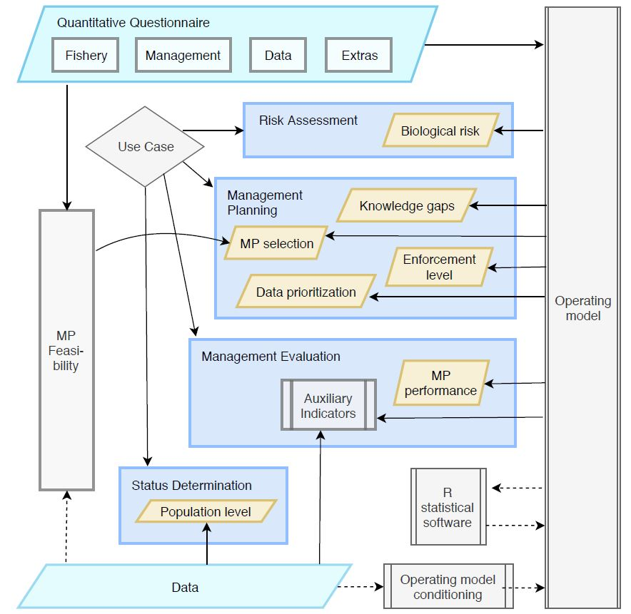

Figure 1.1. MERA components and workflow.

## 1.3 The scientific background to MERA

### 1.3.1 The need for informed management

Fisheries management systems typically involve an ongoing cycle of harvest, data collection, data processing, resource assessment, management recommendations and enforcement of management measures (Walters and Martell 2004). Fisheries managers are embedded in these systems and must make critical decisions, many of which are often poorly informed.

For example, managers must apportion budgets among various species and competing programs such as data-collection, scientific research, resource assessment and enforcement. Managers must select an appropriate time interval for renewing management advice and the correct level of model complexity for assessing a stock. They must also select among many ways to interpret stock assessment outputs in terms of management advice (i.e. a harvest control rule). Additionally managers may be expected to guide their science program in the direction of the most critical uncertainties in the system that are most in need of research.

### 1.3.2 Options for informing strategic management

There are two options for evaluating competing modes of management in order to inform management strategy: experimentation and theoretical modelling. Exploited ecological systems are a notoriously challenging subject for theoretical systems modelling. Due to biological, behavioral and ecological complexities (Rouyer et al. 2008, Sugihara et al. 2011), shifting productivity (Vert Pre et al. 2013), changing environmental conditions, unobserved exploitation (Agnew et al. 2009), variable quality of data and many other factors besides, models may be an inadequate representation of the system, failing to capture critical system dynamics and providing unreliable predictions.

Empirical testing recognizes these difficulties and evaluates alternative management modes applied in practice to the real system. However, for practical reasons the experimental approach is not feasible for most fisheries. Experimental replication is not possible when the subject is a single fish stock existing in a unique ecological setting precluding rigorous and statistically valid empirical evaluation. Even if it were feasible, the statistical power to detect system changes over relevant time horizons may be expected to be low and experimentation expensive, accounting for the costs of additional data collection and lost fishery yields. For such reasons, proposed experimental approaches to fishery management such as adaptive management (Holling 1978, Walters 2002) have not seen widespread adoption despite their empirical advantages (Walters 2007, Westgate et al. 2013).

The alternative, theoretical testing, relies on the development of representative systems dynamics models (operating models) to evaluate the expected performance of candidate management modes. While operating models can be used to inform a wide range of management questions, previous applications in fisheries have generally focused on Management Strategy Evaluation (MSE) in which various ways of setting management advice using data (‘management procedures’) are comparatively evaluated (Butterworth and Punt 1999, Punt et al. 2016).

While there have been criticisms of operational modelling (Rochet and Rice 2009, in reference to MSE), the potential advantages of the approach have made it on ongoing priority for developed fishery management systems at various scales for example, US state fisheries (CDFW 2018), federal fisheries in the US (NOAA 2019) and Canada (Kronlund et al. 2013) and for high seas tuna stocks (Anon 2018). Prevailing obstructions to more widespread development and adoption of operating models include relatively high costs (compared with a one-off assessment of the population) and the availability of suitably qualified analysts and data to inform various scenarios for system dynamics.

### 1.3.3 Contemporary approaches for informing fisheries management

In the absence of rigorous operational modelling, fisheries resource management has often relied on subjective, qualitative frameworks for guidance. A large number of such frameworks exist that aim to evaluate biological risks (Productivity Susceptibility Analysis, PSA: Hobday 2007), stock status (Rapfish; Pitcher 1999), select management options (FISHE: EDF 2019) and prioritize management issues (Fletcher 2005). Such systems have been used widely. For example, PSA has been used in the eco-certification of global fish stocks (Seafoodwatch 2016) and satisfied legal requirements for ecosystem-based fishery management (Hobday et al. 2011).

Since they simply formalize expert judgement into a scoring system that accepts subjective inputs, it is hard to objectively evaluate both the validity of their assumptions and the quality of advice that they provide. When such systems have been codified and subject to theoretical testing their performance was found to be poor (e.g. biological risk assessment using PSA, Hordyk and Carruthers 2018).

### 1.3.4 MERA objectives

The primary objective of the MERA software (Carruthers et al. 2019) was to provide an accessible tool for the construction of operating models enabling fishery managers to make informed strategic decisions at various levels including data collection, species prioritization, MP selection and enforcement.

A secondary objective was to support an accessible user interface with sophisticated models and statistical libraries to allow for state-of-the-art operational modelling and MSE when required. Thirdly, MERA was designed to be applicable to the widest range of fisheries possible, various in their scientific understanding, data availability, biological, ecological and exploitation characteristics.

Lastly, MERA had to be customizable and inform diverse user groups including regional fishery management organizations, international development agencies such as the UN Food and Agricultural Organization and seafood certification bodies such as the Marine Stewardship Council

# 2 Questionnaire

## 2.1 Fishery Questions

The Fishery panel is a set of questions about the characteristics of the fish population and its fishery.

### 2.1.1 Fishery description

Describe the fishery you are modelling and identify yourself and the relevant management agency.

The ‘number of years’ is important and will be used to simulate your historical fishery. It is the total number of years that substantive fishing (that could impact the stock) has been operating for. So for example, if it is 2020 this year, and the fishery began in 1981, this would be 40.

The text input box provides a place for you to document important qualitative aspects of the fishery that provide necessary context for the questionnaire including

1. The history and current status of the fishery, including fleets, sectors, vessel types and practices/gear by vessel type, landing ports, economics/markets, whether targeted/bycatch, other stocks caught in the fishery.
2. The stockâs ecosystem functions, dependencies, and habitat types.
3. Any relevant reference materials and supporting documents, such as stocks assessments, research, and other analyses.

### 2.1.2 Longevity

How long lived is the fish species? This is a critical input determining stock productivity. The parameter M is the instantaneous natural mortality rate. For a review of data-limited methods of estimating M see [Kenchington (2014)](http://onlinelibrary.wiley.com/doi/10.1111/faf.12027/abstract).

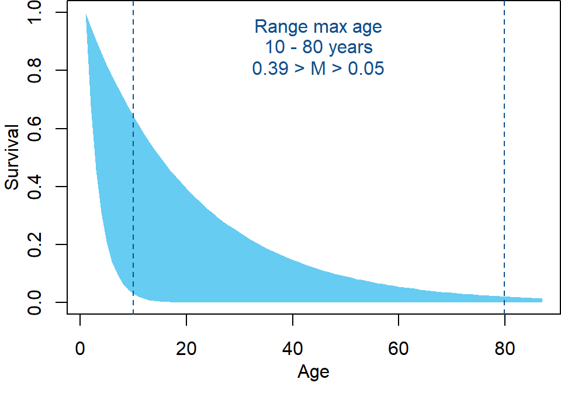

Figure 2.1. Longevity expressed as ‘maximum age’ and the instantaneous natural mortality rate M.

### 2.1.3 Stock depletion

Depletion D, refers to current spawning stock biomass relative to unfished.

Since depletion is a data-rich quantity it may not be readily quantified and it may be necessary to specify a wide range of uncertainty for this input to identify MPs that are suitably robust.

In a data-limited situation, coarse information regarding depletion may be obtained from examining length compositions, historical versus current catch rates, or by use of so-called Robin-Hood approaches.

For further information see [Carruthers et al. (2014)](http://www.sciencedirect.com/science/article/pii/S0165783613003081) and [Punt et al (2011)](https://academic.oup.com/icesjms/article/68/5/972/653125/Among-stock-comparisons-for-improving-stock)

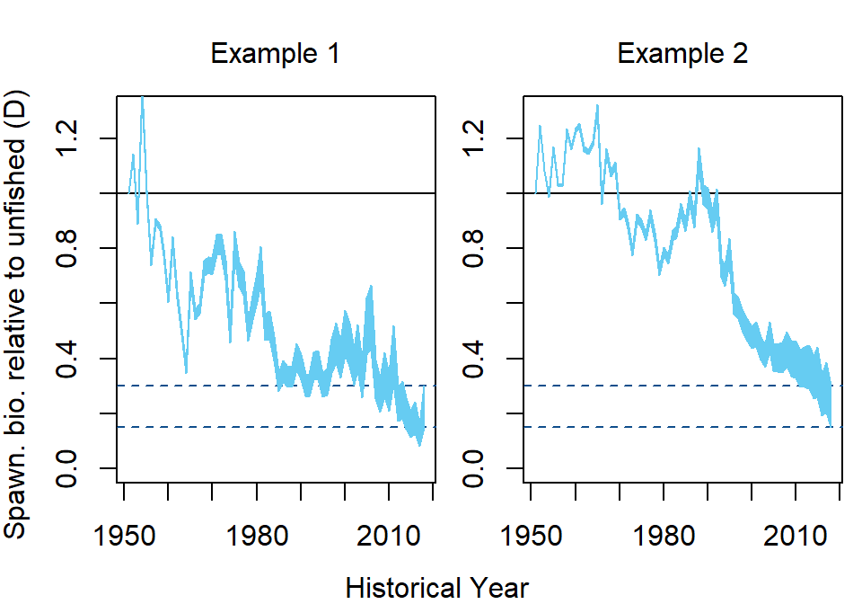

Figure 2.2. Stock depletion - current spawnign stock biomass relative to ‘unfished’ levels.

### 2.1.4 Resilience

How resilient to exploitation is the stock? This question controls recruitment compensation - the extent to which recruitment is reduced from unfished levels (R0) as the spawning stock becomes increasingly depleted below unfishe levels (SSB0). Here resilence is expressed in terms of steepness (h): the fraction of unfished recruitment at 1/5 unfished spawning biomass.

For a useful review of compensatory density dependence in fish populations see [Rose et al. (2001)](http://hqczhzkgch48vzcc4czubj6v.wpengine.netdna-cdn.com/files/2012/07/Rose_etal_FishFisheries.pdf).

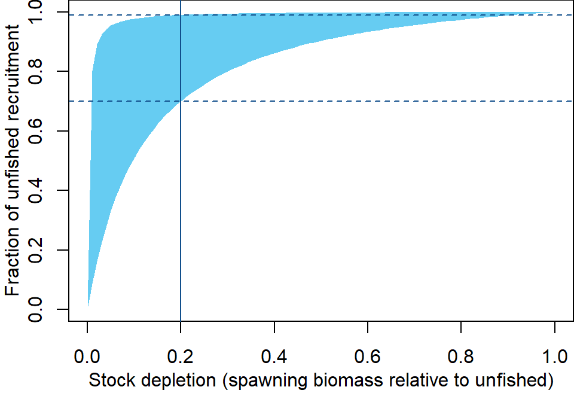

Figure 2.3. Stock resilience expressed as steepness: the fraction of unfished recruitment expected to occur at 1/5 unfishned spawning stock levels.

### 2.1.5 Trend of historical exploitation

What temporal pattern best describes the trend in historical exploitation rates (aka fishing mortality rates or F)? If more than one answer is given, historical fishing will be simulated subject to all trends in equal frequency. If it can be assumed that fishing effort is proportional to exploitation rate this can be summarized as historical patterns in fishing effort (e.g. boat-days per year, number of trips per year). This set of answers specified the possible range of mean trends, you will have an opportunity to adjust the extent of interannual variability in the following question. Here is a basic introduction to fishing effort and the assumption of proportionality courtesy of the [UN FAO](http://www.fao.org/docrep/x5685e/x5685e04.htm).

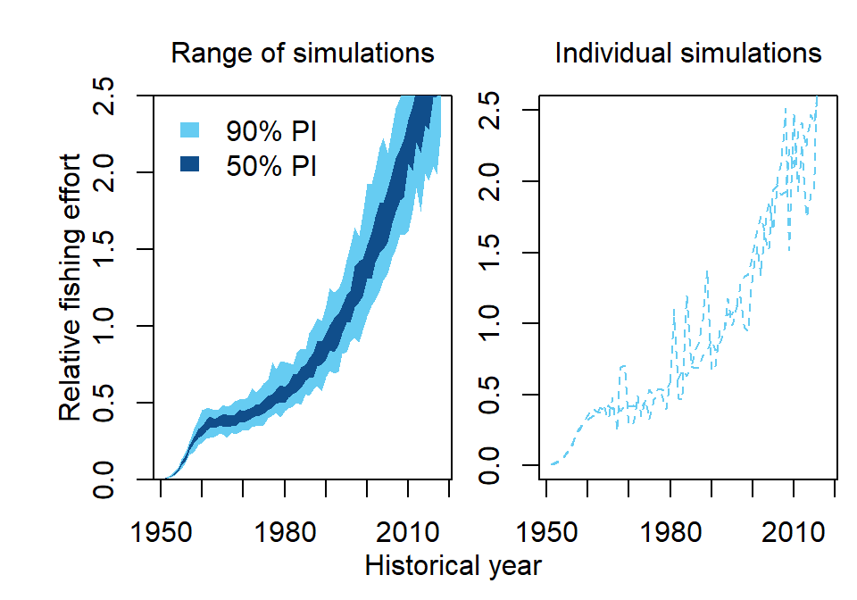

### 2.1.6 Variability in historical exploitation

The extent of interannual variability in historical exploitation rates around the mean trend(s) specified in Fishery question #5. Again, here is the introduction to effort and exploitation rate by the [UN FAO](http://www.fao.org/docrep/x5685e/x5685e04.htm).

### 2.1.7 Selectivity relative to length at maturity

Fishing gear selectivity relative to size at maturity (S). For example, if 50% of 40cm fish are caught by the gear and length at 50% maturity is 50cm, S = 4/5.

The UN FAO explain something of fishing gear selectivity and how it may be quantified in an [introductory document](http://www.fao.org/docrep/w5449e/w5449e08.htm). For a more involved discussion on selectivity see the [IATTC CAPAM workshop report](https://swfsc.noaa.gov/publications/CR/2013/2013Crone.pdf).

### 2.1.8 Selectivity of large fish

Fishing gear selectivity of the largest individuals (SL). For example, if only 20% of the longest fish are caught by the gear SL = 0.2. Again here is the [FAO introductory document](http://www.fao.org/docrep/w5449e/w5449e08.htm) and the [IATTC CAPAM workshop report](https://swfsc.noaa.gov/publications/CR/2013/2013Crone.pdf).

### 2.1.9 Discard rate

Discard rate (DR). What fraction of fish that are caught are discarded (includes fish that are dead and alive)?

The US National Marine Fisheries Service have a [general guide to Understanding Fish Bycatch Discard and Escapee Mortality](https://www.afsc.noaa.gov/quarterly/jfm03/featurejfm03.pdf) and one of the authors of that guide, Michael Davis also has a useful article: [Key principles for understanding fish bycatch discard mortality](https://swfsc.noaa.gov/publications/CR/2013/2013Crone.pdf).

### 2.1.10 Post-release mortality rate

Post-release mortality rate (PRM). What fraction of discarded fish die after release?

Again here is NOAA’s [general guide to Understanding Fish Bycatch Discard and Escapee Mortality](https://www.afsc.noaa.gov/quarterly/jfm03/featurejfm03.pdf) and one of the authors and the article fo Michael Davis: [Key principles for understanding fish bycatch discard mortality](https://swfsc.noaa.gov/publications/CR/2013/2013Crone.pdf).

### 2.1.11 Recruitment variability

Interannual variability in recruitment (the coefficient of variation in log-normal recruitment deviations, sigma R). Recruitment is expected to change among years in response to changing spawning biomass levels. On top of this is additional variability that may be driven by many factors including varying ocean conditions, amount of spawning habitat, food availability and predation. Sigma R controls the extent of this additional variability in annual recruitments. For example, a sigma R of 10% means that 95% of recruitments will fall in approximately 80-120% of the mean recruitment predicted from spawning biomass.

Edward Houde authored a [Comprehensive Review of Recruitment and Sources of Variability](https://drive.google.com/open?id=19q_ct4Xd954H2jjotX3YKy0BJ-v53bt2) and if that isn’t sufficient there is [Chambers and Trippel (1997)](https://drive.google.com/open?id=1KhwP5URGPzW6ViJPiwprfY2tE2uucpDR).

### 2.1.12 Changing fishing efficiency

The annual % increase/decrease in fishing efficiency (q). In targetted fisheries gear efficiency may improve over time given techological improvements in the gear, bait, fish location, sharing of information etc. Conversely, non-target or bycatch species may be subject to declining fishing efficiency due to regulations or avoidance behaviors. The catchability q is the fraction of available fish caught per unit of effort. For example, a 2% per annum increase in fishing efficiency means that after 35 years twice as many fish will be caught for the same effort as today.

The introduction to fishing efficiency by the FAO provides a [basic summary](http://www.fao.org/docrep/008/y6982e/y6982e06.htm). Alternatively there is a more comprehensive review by [Arrenguin-Sanchez](https://drive.google.com/open?id=1ZrHbhotCJ5Vjw4JNloUSY94BVoM0iyfI).

### 2.1.13 Size of potential / existing marine reserve

The size of a potential or existing spatial closure (Marine Reserve). The size A is the % of habitat that is protected.

The FAO provides a [comprehensive review of Marine Protected Areas](http://www.fao.org/docrep/015/i2090e/i2090e.pdf).

### 2.1.14 Spatial mixing (movement)

The degree of stock mixing. The probability P of a fish leaving area 1 (ie. the MPA) between years

The FAO provides a [comprehensive review of Marine Protected Areas](http://www.fao.org/docrep/015/i2090e/i2090e.pdf).

## 2.2 Management Questions

The Management panel is a set of questions about what fishery management options are available and how well management advice is followed.These questions:

- identify what management procedures are feasible given the types of management measures.
- determine the relative success of various management procedures that provide different types of advice.

### 2.2.1 Types of fishery management that are possible

Here you indicate which MPs are feasible given the management options that are available. Management procedures can provide management advice in terms of:

- Total Allowable Catch limits (TACs, e.g. 20,000 metric tonnes).
- Total Allowable Effort (TAE, e.g. 800 trap days per year).
- Size limits (e.g. minimum size of 45cm).
- Time-area closures (e.g. closing an area to fishing, an MPA or a Winter closure.

For more information see the UN FAO [guide to fishery management types](http://www.fao.org/docrep/005/y3427e/y3427e06.htm).

Or alternatively, Steffanson and Rosenberg describe and discuss fishery managment types in their [2005 paper](https://drive.google.com/open?id=1V5aMNf3raitNC515qyFfITDivgbXkU4X).

### 2.2.2 Implementation uncertainty: consistent overages/underages

What is the possible extent to which fishing operations may exceed (overages) or fall short (underages) with respect to the specified Total Allowable Catch (TAC)and Effort (TAE)? For example, given a TAC of 1000 tonnes and a TAE of 2000 boat-days of fishing a 10% overage would on average lead to 1100 tonnes of fish taken and 2200 boat days of effort.

The FAO provides a cursory introduction to uncertainties in fisheries management including implementation error [here](http://www.fao.org/docrep/003/v8400e/V8400E03.htm).

Fulton et al. provide a discussion of implementation error in their [2011 paper](https://drive.google.com/open?id=1gzTMnk3Cg3PzgxDdKAyV52T9IIptUK7h).

### 2.2.3 Implementation uncertainty: variability

The FAO provides a cursory introduction to uncertainties in fisheries management including implementation error [here](http://www.fao.org/docrep/003/v8400e/V8400E03.htm).

## 2.3 Data Questions

The Data panel is a set of questions about what types of data are available and quality of the data that are available. These questions: * identify what management procedures are feasible given the types of data available. * determine the relative success of the various management types that rely on differing types of data.

### 2.3.1 Types of data that are available

Management procedures require various data. Where data types are unavailable some MPs may not be feasible.

Annual catches are yearly reporting landings (e.g. 135 tonnes in 1998, 159 tonnes in 1999, etc).

Relative abundance indices may be fishery-dependent such as catch-per-unit-effort data or fishery-independent such as an annual abundance survey.

In the context of annual catches and relative abundance indices, ‘historical’ refers to data going back to ‘unfished conditions’ (pre industrial fishing) such that catches may be used to reconstruct stock trajectory and indices may infer current stock depletion. In contrast, ‘recent’ refers to data available for least 5 years from today.

Effort data are annual observations of fishing effort such as boat days in 2002.

Growth data refers to parameter estimates for growth parameters such as von Bertalanffy growth parameter K and mean asymptotic length, L-infinity.

Size and age composition data are samples of size and ages in the catch going back at least 2 years from today.

### 2.3.2 Catch reporting bias

Under reporting of catches In some data-limited fisheries, incomplete monitoring of fishing operations may lead to under-reporting (and to a lesser extent over reporting) of annual catches.

For further discussion of catch under reporting see [Agnew et al. (2009)](https://www.ncbi.nlm.nih.gov/pmc/articles/PMC2646833/).

### 2.3.3 Hyperstability in indices

Is the primary index of relative abundance proportional to real biomass? Indices of relative abundance derived from fishery catch-per-unit effort may decline faster than real abundance (hyperdepletion) in cases where, for example, the species is being avoided or there has been attrition of high-density sub-population structure during early commericial fishing.

Conversely catch per unit effort data may respond slower than real biomass changes if the species is being targetted, there is range contraction of fishing toward high density areas as the stock declines or the population naturally forms aggregations. For example purse-seine fisheries are often strongly hyperstable since the fish per aggregation may remain high even at low stock sizes.

It may be generally assumed that a well designed fishery-independent survey is proportational to abundance but there are notable exceptions.

See [Erisman et al. (1992)](https://drive.google.com/open?id=1jwhIGfTmXewKWGSTNyyjoo4TefW2JiNR) or [Maunder et al. (2006)](https://drive.google.com/open?id=1chNF72tCB_fjTjbbhZk7EyxtRU810EIc).

### 2.3.4 Overall data quality

What is the overall quality of data that are available?

- Perfect Information: An unrealistic and idealized observation model for testing the theoretical performance of MPs.
- Good quality: annual catches and abundance indices are observed with low error (<20% CV) and length/age composition data are numerous (~100 independent observations per year).
- Data moderate: annual catches and abundance indices are observed with greater error (<30% CV) and length/age composition data are fewer (~40 independent samples per year).
- Data poor: annual catches and abundance indices are imprecisely observed (<50% CV) and length/age composition data are sparse (~15 independent samples per year).

A description of the observation error model is included in [Carruthers et al (2013)](https://drive.google.com/open?id=1EX6mu9HOb4jwlQF-Co6DQ-FJzwTcO7JP) and a similar model was used by [Carruthers et al. (2015)](https://drive.google.com/open?id=1xvNxp_3oUOhSaLARY_mI2cAiG2qFAgqN).

## 2.4 Optional extras

### 2.4.3 Short-lived extensions

# 3 Risk Assessment Use Case

## 3.3 Interpreting results of risk assessment

### 3.3.1 Projection plots

The risk assessment use case provides a projection plot showing the 90% (light blue) and 50% (dark blue) probability intervals, the median estimate (white line) and two example simulations (dark blue lines).

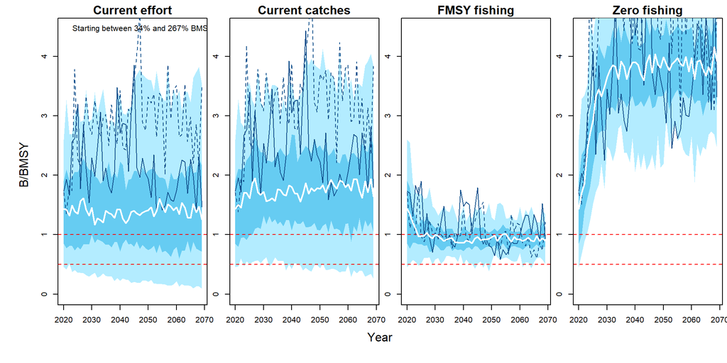

Figure 1. Risk assessment projection plots for current effort (CurE), current catches (CurC), FMSY fishing (FMSYref) and zero fishing (NFref).

### 3.3.2 Risk assessment table

The results of the projection are also tabulated.

Table 1. The probability that biomass is greater than half BMSY in future years.

|  | MP | 2020 | 2025 | 2030 | 2035 | 2040 | 2045 | 2050 | 2055 | 2060 | 2065 |
| --- | --- | --- | --- | --- | --- | --- | --- | --- | --- | --- | --- |
| 1 | Current effort | 95.8 | 89.6 | 89.6 | 91.7 | 91.7 | 85.4 | 85.4 | 87.5 | 83.3 | 83.3 |
| 2 | Current catches | 95.8 | 100 | 100 | 97.9 | 93.8 | 95.8 | 95.8 | 95.8 | 97.9 | 89.6 |
| 3 | FMSY fishing | 95.8 | 100 | 100 | 100 | 93.8 | 97.9 | 97.9 | 100 | 97.9 | 97.9 |
| 4 | Zero fishing | 95.8 | 100 | 100 | 100 | 100 | 100 | 100 | 100 | 100 | 100 |

## 3.4 An example risk assessment

# 4 Management Planning Use Case

## 4.1 Background to risk assessment

# 5 Management Performance Use Case

## 5.1 Background to risk assessment

# 6 Status Determination Use Case